# 📃 CHANGELOG WEDNESDAY DECEMBER 6TH ("MASTERPIECE")

#### Phase 4

- Presentation adjusted for Phase 4
- Explanation of my goal of the demonstration has been added
- A bit of background info about my stakeholder is added for context
- Feedback received from my stakeholder has been summarized and contextualized
- A "closing thought/conclusion" chapter has been added

# 📃 CHANGELOG SUNDAY NOVEMBER 26TH ("MASTERPIECE")

#### General

- Presentation added for Phase 4

#### Social impact

- Sources readjusted to conform to APA style
- Phase 4: "Delivery" incorporated

#### Machine learning

- Added some visuals to explain certain decisions "easier"

# 📃 CHANGELOG WEDNESDAY NOVEMBER 15TH ("NEXT ITERATION")

#### Social impact

- Feedback incorporated: "What do experts say is the influence of social media in polarization (if any)?"

#### DAIA

- New chapters added and filled out in accordance to the AI Project methodology
- Feedback incorporated: "What columns did you add, why did you do it and how did you do it."
- Feedback incorporated: "please put (non-trivial) comments on your code (steps) in Markdown instead of Python comment"
- Feedback incorporated: "why are you specifically interested in the like and retweet numbers and the amount of tweets?
- Feedback incorporated: "What is it that you want to discover or lay bare in the data?"
- Feedback incorporated: "How does it help you to create a better prediction model?"
- Feedback incorporated: "What do the visualizations reveal?"

# 📃 CHANGELOG MONDAY NOVEMBER 13TH ("NEXT ITERATION")

#### No new changes in this iteration for DAIA/SOCIAL IMPACT. This is mainly to bring the machine learning part up to par with some minor general notebook improvements.

#### Next iteration later this week will have a complete improvement with most recently given feedback incorporated.

#### General

- Table of contents updated to reflect AI Project Methodology

#### Dataset itself

- I have labeled an additional ~1000 more tweets with subjects to a total of ~2000 tweets
- Excluded "unspecific" label from my model

#### Machine learning

- Sample size and max word adjusted
- Nearest Neighbours have been tested and applied as a reference
- Stratified K-fold validation
- Stop words list added for a better model
- Overall story telling added/improved

# 📃 CHANGELOG SUNDAY NOVEMBER 5TH ("NEXT ITERATION")

#### Dataset itself

- I have labeled ~1000 more tweets with subjects to a total of 1188 tweets
- I have changed some labels and added a few to a total of 8 subjects (excluding "unspecific/undefined")
- I added new columns to be able to support more EDA (more explanation about what specifically can be found under in the EDA chapter)

#### EDA

- EDA chapter has been created
- Classes are created for time of the day and day of the week, which are then put in 2 respective columns
- Some starting EDA has been done and conclusions have been drawn

#### Domain understanding

Domain understanding chapter has been updated based on John's feedback to show the following:

- "How is the turkish situation the same and-or different from polarisation in general i.e. in UK or USA if at all?"
- "How is the role of the specific medium Twitter / X? Does it make a difference or is this the same as any social media platform?"
- "Is polarisation 'of all times' or specific to us?"
- "However you should still sketch this grand scheme of things for the reader in a next iteration further."
- "How will this affect the future of social media and the public 'debate'?"

#### Machine learning code

- Sample size and max word adjusted
- Nearest Neighbours have been tested and applied (on hold for this iteration)

# Case of a polarized Turkey

### Phase 1: Proposal

- Introduction
- Domain understanding
- Data sourcing
- Analytic approach

### Phase 2: Provisioning

- Data Requirements
- Data Collection
- Data Understanding and Data Preparation

### Phase 3: Predictions

- Preprocessing
- Modelling
- Evaluation

### Phase 4: Delivery

- Demonstration
- Feedback
- Final thoughts and conclusion

# Introduction

Deciding on what I wanted to do my personal AI challenge on initially was a challenge by itself. I brainstormed several ideas by myself but none of them made me feel particularly excited to do. My mild "excitement" always died out after I asked myself: "Why?".

I struggled to see why I(or anyone else for that matter) would need whatever program it was I came up with. It all felt too bland to me.

Shortly thereafter during a social impact lecture, me and some other students were having a conversation with John where he asked us if we already had any potential ideas for the challenge. Most of us gave some answers, but one particular comment by John got me thinking. "What is the actual impact or potential you want your program to have to the outside world?"

Somehow this unraveled a lot more questions I was asking myself in my search to this idea. What was it indeed that I was trying to achieve? Do I just want to do the bare minimum, pick a topic that is as easy as possible just to pass this semester? What am I looking to get out of this in terms of my own personal development? Would I care at all anymore about it after the challenge was finished and completed?

I didn't believe it would do my hunger in my journey to getting my Bachelors any justice if I did something I didn't really care about. Or something that was just barely interesting enough for me to stay motivated on actually carrying it out throughout the semester.

So after some more digging, and without any specific segue, I decided to see if I could create something that could potentially bring more insight to an incredibly complex topic and situation, which I'm personally seeing the many consequences from in my enviroment.

If you didn't already guess from the title, the topic of my AI challenge is political polarization. Specifically political polarization in my mother country; Turkey.

In Turkey, one of the biggest social media channels ESPECIALLY in the political area is twitter. From politicians, to business executives, all the way to "regular" people use twitter as a way to discuss, express, and keep up with the latest regarding any form of politics. Because it is incredibly relevant, I decided to use twitter as the input to the program I want to create.

I am going to create a program that can analyze text (tweets in this case) and predict which political topic the tweet is about. (And if time/scope allows, also what the sentiment of the tweet is)

Now as to why. Why would I do this challenge? I don't think I need to put in a lot of effort to convince people why polarization is a less than ideal situation no matter the country. It is indeed a problem. A problem because of the divisiveness it creates in society.

But how can I, a student solve such a big and complex issue which huge governments in the world can't even solve?

The obvious truth, is that I can't. But that's also not what my program intends to do. The real reason for me to start my project is to bring more insight, context, and general understanding TO the case of polarization. Maybe this tool can help people do things such as identifying echo chambers, maybe help an analyst with their research, or maybe even promote more fact-checking.

I can't tackle such a huge and complex issue. But I can break it down and get somewhere where I CAN do something, even if it is on the grand scheme of things a small thing.

To list my requirements simply; I need tweets. As many as I can find.

# Domain understanding

Political polarization means that there are two obvious(and opposite) peaks of opinion in the political sense. It can be observed through people's various choices, sociopolitical approaches, and even where they live.

Turkey has always been a country of many different ideologies. There have been periods of time people defined themselves according to their political views. There are different classifications of ideologies in the Turkish system. Most common two of these are based on religion and ethnicity. This is where most of the current political polarization springs from; Religion and Secularism.

It is safe to say that polarization has changed many aspect of the country from media to social relations. Polarization is more than just a political concept. It affects and is affected by many factors, such as coalition governments, multi-party legislatures, great wage gaps, multiethnic societiesm and a low level of trust.

The beginning of modern Turkey's polarization is in the foundational reforming of the 1920s that sought to remove religion from public life and thus created a political and cultural divide between secularism and religion. After the collapse of the Ottoman Empire following the end of WW1, the founder of modern Turkey (Mustafa Kemal Atatürk) went ahead to transform the nation along Western secularist lines.

He abolished the caliphate(Islamic form of government), replaced Sharia courts with a secular civil code, and placed all religious institutions under state control to monitor and strictly limit the role that religion would play in public life.

In other words; separating church from state.

While secularism and religion still play a huge role in the foundation of Turkey's polarization. In the 21st century it is directed more towards two sides. Pro Erdogan, and anti Erdogan.

Namely, there were some bigger events regarding the two camps that contributed a lot towards this polarization.

In 2016 a faction within the Turkish Armed Forces attempted a coup against state institutions, including the government and president Recep Tayyip Erdogan. They attempted to seize control of several places in Ankara, Istanbul and Marmaris. They failed however, after armed forces and civilians loyal to the state defeated them. The Council cited an erosion of secularism, elimination of democratic rule, disregard of human life, and Turkey's loss of credibility in the internation arena as reasons for the coup. The government under Erdogan said it had evidence the coup leaders were linked to the Gülen movement, which is designated as a terrorist organization by the Republic of Turkey and led by Fethullah Gülen, a Turkish businessman and a well-known Islamic scholar who lives in exile in Pennsylvania. Events surrounding the coup attempt and the purges in its aftermath reflect a complex power struggle between Islamist elites in Turkey.

In 2018, Turkey conducted a highly consequential election in which the Turkish people elected their president and parliament in the first election under a new presidential system. Of course as mentioned before, Turkey already has experienced significant political polarization in recent years, primarily between two major camps: the ruling "Justice and Development Party" (AKP) led by current President Erdoğan, and the opposition parties, notably the "Republican People's Party" (CHP) and the "Peoples' Democratic Party" (HDP).

The AKP has dominated Turkish politics since 2002, promoting conservative and Islamist policies, leading to a divide between its supporters, who often prioritize religious values, and its critics, who emphasize secularism and democracy.

The transition to a new presidential system and allegations of electoral manipulation have fueled mistrust in the whole process. On the 9th of July, two weeks after his re-election, Turkish President Erdogan replaced its parliamentary system with one concentrating virtually all political power in the presidency. This has raised concerns in Turkey and throughout the world in foreign affairs.

The Turkish people, who already had a large divide, started to get even more divided between themselves.

The relation between social media (twitter in this case) and polarization also becomes apparent when analyzing general sentiment. Out of ±84 million people in Turkey, ±20 million people have twitter. (Oberloo, 2023)

This is a huge proportion. And the reason why I'm analyzing polarization through twitter and not other forms of social media.

## Is Turkey's situation different from other countries? (USA, UK in this context)

While Turkey's situation share some examples that can be the same with other countries like the USA and the UK, there are also significant differences due to the unique political, historical, and cultural contexts of each country.

As for political polarization, there seem to be a big similarity in the "black/white" sense. In the USA it could be due to the two-party system which represent a distinct position of each other. (Pew Research Center, 2024)

With the UK it is largely about the Brexit debate, with a huge portion of the country being Pro-Brexit, and an almost equal portion of the country being Anti-Brexit. (Wikipedia, 2016)

As mentioned before, in Turkey it is mostly centered around more conservative and Islamist policies, and the opposite side who emphasize secularism and democracy.

So while these situations share a big divide between 2 camps, the reasons are mostly unique to each country. The biggest difference in why the 2 -party-divide differs from each other could be related to Religion. (Brookings, 2018) [.](https://www.brookings.edu/wp-content/uploads/2019/04/9780815737216_ch1.pandasf)

## Does Twitter even differ from other social media platforms?

In my anecdotal evidence, it doesn't differ that much. Platforms such as TikTok have loads of posts and videos with the same messages both camps yell out but in different media forms.

May it be a video, or text, the messages are still being distributed.

One could argue however that video could be more impactful to sway opinions, and that text is more useful in actual discussions and raising the voice behind the polarization.

A specific subject is equally feasible on both platforms; fake news.

Now especially with the help of GPT and DALL-E or any other AI for example, it is a lot easier to create and distribute fake news. What the actual impact of this is would need its own project. (The Guardian, 2023)

So why my choice for Twitter for this project? As mentioned before, Twitter is very widespread in Turkey and used daily in large amounts. The medium also fits the requirements for my actual AI program.

## "This polarization you keep talking about, is this something only we experience because of social media?"

Polarization has been a tale as old as time. Of course the specifics that fuel polarization may change over time, the fundamental concept of "black/white" divisions in various countries is nothing new.

Take Ancient Greece for example. Athens and Sparta had deep political and cultural divisions. The Peloponnesian War (between 431 and 404 BC) was partly the reason because of these divisions. (Rachel Hadas, 2023, Wikipedia, 2023)

A more recent example could be the American Civil War. That is a well-known example of political polarization. The conflict between the North and South in the USA was from deep political, economic, and ideological differences. Namely regarding slavery. (PBS, 2003)

## The influence of social media in polarizaion. Or is there?

Recent research says that social media can fuel the effects of polarization by basically adding "water on burning oil". The extent to which polarization is done by online echo chambers or social bubbles is however not well understood. (Christian Baden & Neta Kligler-Vilenchik, 2020)

There is however still big portion of scholars that say that social media are indeed fueling it more and more, especially in established democracies like the US or UK. Jamie Settle's work shows with surveys and experiments that polarization is actually very likely to rise. (Jaime E. Settle, 2018)

Another study done by Hunt Allcott also concurs. (Hunt Allcott, 2020)

But on the opposite side, Ashley Johnson says that blaming social media for political polarization is misguided. Existing research does not support the claim that social media is driving political polarization. Arguments are made that these sentiments are just reflecting offline happenings. "People with similar beliefs may naturally cluster together in online communities, just as they do offline." (Ashley Johnson, 2023)

The above does however not touch upon if this amplifies a pre-existing division, or amplifies in more extreme "voices" because of the nature of the internet; being easy, anonymous, everyone having a voice etc.

## Why is polarization seen as negative on the "grand scheme of things"?

Polarization, when people strongly disagree on things like politics or culture, could cause several problems. One big issue is that it makes it hard for people to get along and work together. Trust in each other can break down, which is important for a functioning society.

In politics, it can get to a point where nothing gets done. People can't find common solutions anymore because they're more focused on sticking to their own opinions instead of also working together to reach common goals. There doesn't always need to be a common goal, but politicians should be able to "rule" the country to its best interest.

Polarization can also make people more stressed and anxious. It can lead to "bubbles" where people only hear what they already believe, making it harder to have a normal conversation, or discussion for that matter. One of the more negative things is that polarization can make some people turn extreme and even use violence to push their ideas and opinions.

So while it's good to have different ideas, when they become too extreme from each other, it could cause many problems. Finding a balance between different thoughts and working together is essential to fix these issues. This means we need to make an effort to understand others and talk to each other in a respectful way, even if we don't agree. This is of course easier said than done, but a functioning and understanding society is vital to progression.

## How could my project affect Social Media and the public debate?

It could be used to promote more fact-checking, potentially reducing the spread of false or misleading information that often contributes to polarization. Though as touched on before, the creating of more "believable" and/or "convincing" fake/misleading information is much more approachable now. That will always be a hard thing to try and eliminate as much as possible.

And by "fixing" extreme disagreements and false info, it can make public talks better. But there are also concerns about privacy and censorship, so it's a tricky balance on how you can even achieve this, and more importantly, the ruleset behind such actions in terms of an ethical point of view. (who decides what is extreme etc.)

It also raises some important questions about how AI in general can be used, or should be used.

# References

# Data sourcing

Data sourcing has proved itself to be very problematic. I am limited by this, but for the time being I will use this collection of Turkish tweets found on [Kaggle](https://www.kaggle.com/datasets/mrtbeyz/trke-sosyal-medya-paylam-veri-seti/data)

From reading through the tweets, it appears to be very random with no real timeline to be deduced.

Initially I signed up for a twitter developer account so I can access the api myself and thus cater my own dataset. This however struck short very quick. The free version only allows for 1500 calls per month. Just experimenting alone to get it right set me to the limit, and I don't have a spare 5000 dollars a month to spend on this project to upgrade my developer account.

Nonetheless, as discussed with the teachers, there are still a lot of things that I can show despite the limitation in data.

The quality of the dataset isn't there yet, but this will be greatly optimized (in this notebook) as this project goes on throughout the semester.

# Analytic approach

Since the dataset is quite limited, it will mostly revolve around the actual text in the tweet itself. This accompanied with the labels that I have set myself to train the model.

Because I'm using labels, the algorithm type will be that of a classification.

Subjects as of now:

- government
- humanities (civil rights, hate-speech etc.)
- economy (inflation, rent, taxes etc.)
- climate
- religion
- welfare
- AKP (AK PARTY - erdogan)
- CHP (CH PARTY - kilicdaroglu)
- unspecific (for anything not in those subjects)

# Data Requirements

### What data do I need to achieve my goal?

To achieve my machine learning goal, I simply need a dataset filled with text data. However, for EDA purposes I like to have some additional types of data to be able to explore my dataset and its context, see if there's anything meaningful I can get out of that to further improve my machine learning modeling.

### For that I would need:

Numerical data:

- Units: Integers
- Range: 0 to undefined range

Datetime data:

- Units: Year, month, day, hours, minutes, seconds
- Range: Last 5 years

Categorical data:

- Categories: Government, Humanities, Economy, Climate, Religion, Welfare, AKP, CHP, Tweeted from device: xyz.

Text data:

- Origin: tweets
- Length: 280 characters maximum

Considering data volume; the more the better. But with a minimum of 500 rows I could do a decent job. Anything less would make it too "random" in its prediction as there are many factors in predicting a subject from a limited amount of words per row.

# Data Collection

As mentioned in an earlier chapter, I will begin a new dataset with tweets from this kaggle dataset: [Kaggle](https://www.kaggle.com/datasets/mrtbeyz/trke-sosyal-medya-paylam-veri-seti/data)

The data is then stored in a .csv file as that is the file extension I will be using to read it in this notebook.

# Data Understanding and Data Preparation

```python
import seaborn as sns
import pandas
import matplotlib.pyplot as plt
import sklearn
%matplotlib inline

pandas.set_option("max_colwidth", 200)
pandas.set_option("display.float_format", '{:.2f}'.format)
random_state = 20
```

In any other situation I would simply filter out rows based on any NA values in the "Subject" column to get the same result with more efficient code. But because I want to keep track of the labels I'm using as a "reminder", I'm filtering the dataset specifically on those.

```python
df = pandas.read_csv("newdata.csv")
df = df.loc[
    (df['Subject'] == 'government') |
    (df['Subject'] == 'humanities') |
    (df['Subject'] == 'economy') |
    (df['Subject'] == 'climate') |
    (df['Subject'] == 'religion') |
    (df['Subject'] == 'welfare') |
    (df['Subject'] == 'AKP') |
    (df['Subject'] == 'CHP')
    ]

df
```

|  | tweet_created_at | source | Tweet | like_count | retweet_count | Label | Subject |
| --- | --- | --- | --- | --- | --- | --- | --- |
| 0 | 2021-03-29 21:21:47+00:00 | Twitter for iOS | doğa ağzımıza sıçsa hakkı var | 13 | 5 | Negatif | climate |
| 2 | 2021-11-25 23:41:39+00:00 | Twitter for iOS | ibrahimin oğlunu koruyan tanrı ben sokayım | 377 | 32 | Negatif | religion |
| 4 | 2021-07-17 16:10:02+00:00 | Twitter for iOS | ben söğüşledim birazda sen söğüşle | 35 | 14 | Negatif | humanities |
| 8 | 2021-11-22 14:18:38+00:00 | Twitter Web App | uzun yolculuklar bile tek bir adımla başlar geleceğin mimarları gençlerimiz atılan ilk adımları var gücümüzle desteklemeye devam ediyoruz | 2611 | 753 | Pozitif | humanities |
| 9 | 2021-11-16 13:55:17+00:00 | Twitter Web App | vallahi aralar istediğimiz tek huzur | 74 | 25 | Pozitif | welfare |
| ... | ... | ... | ... | ... | ... | ... | ... |
| 11980 | 2021-10-11 19:29:59+00:00 | Twitter for iOS | Sosyal hizmetler, insanların daha iyi bir yaşam sürmesine yardımcı olur. | 55 | 2 | NaN | welfare |
| 11981 | 2021-10-10 15:03:30+00:00 | Twitter for iOS | İnsanların psikolojik sağlığı, toplumun genel refahını etkiler. | 693 | 3 | NaN | welfare |
| 11982 | 2021-10-09 13:46:15+00:00 | Twitter for iOS | Sosyal yardım programları, yoksulluğun etkilerini hafifletir ve toplumu güçlendirir. | 39 | 2 | NaN | welfare |
| 11983 | 2021-10-08 14:12:52+00:00 | Twitter for iOS | Eğitim, gençlerimizi geleceğe hazırlayarak ülkenin potansiyelini artırır. | 71 | 15 | NaN | welfare |
| 11984 | 2021-10-07 17:32:04+00:00 | Twitter for iOS | Sağlık hizmetlerinin erişilebilir olması, her vatandaşımızın sağlığını koruma hakkını destekler. | 47 | 69 | NaN | welfare |

2049 rows × 7 columns

I chose to add some columns for EDA purposes. I did this in Excel, and collected randomized mock data through [Mockaroo](https://www.mockaroo.com)

With that in mind, understand of course that the EDA results themselves will be nonsense because of the added columns with random data. Though as Marco told me as well, the approach, interpretation, and possible conclusions drawn are more important than the results to demonstrate my LOs. As was said to me; "At the end of the day, you're not a politician; you're an IT student."

I added a timestamp so I can create visualizations to see if I can observe any trends in tweet activity over certain day and time groups. For those I will go for Weekday/Weekend, together with Morning/Afternoon/Evening. I chose to keep it concise because of the limited available data, to not seperate it too much where the results become too inconclusive.

Columns like_count and retweet_count will be used to see which subject has more outreach compared to the other subjects in this dataset. I'm hoping it could bring me better understanding in differentiating the popularity of the different subjects.

Column "source" will be used to show what subjects are tweeted at from what kind of device.

There are some NA values as well in the source of the tweets, for EDA purposes I will fill the NAs with "undefined" because I don't want to lose the tweet all together since it is still useful for my machine learning process in this notebook.

```python
df['source'] = df['source'].fillna('UNDEFINED')

df.sample(5)
```

|  | tweet_created_at | source | Tweet | like_count | retweet_count | Label | Subject |
| --- | --- | --- | --- | --- | --- | --- | --- |
| 11707 | 2021-12-30 17:17:36+00:00 | Twitter Web App | Dini liderler toplumun sorunlarını ele alabilir. | 491 | 25 | NaN | religion |
| 432 | 2021-10-30 16:29:07+00:00 | Twitter Web App | vatan haini | 24 | 2 | Negatif | government |
| 11489 | 2021-08-19 19:01:20+00:00 | Twitter for Android | Hane halkı borçları artıyor, tasarruf önemli. | 45 | 4 | NaN | economy |
| 11697 | 2021-03-26 14:41:16+00:00 | Twitter for iOS | Laiklik, farklı inançları korumalıdır. | 28 | 1802 | NaN | religion |
| 11367 | 2021-10-22 01:34:51+00:00 | Twitter for Android | Enflasyonun düşmesi için tedbirler alınmalı. | 28 | 14 | NaN | economy |

Here I will use the datetime column to create 2 new columns for date of the week, and time of the day.

By doing this it gives me additional flexibility in how I want to use these types of data to gain more context to the dataset by EDA.

```python
df['tweet_created_at'] = pandas.to_datetime(df['tweet_created_at'])

df['dotw'] = df['tweet_created_at'].dt.dayofweek  # Monday=0, Sunday=6
df['dotw'] = df['dotw'].apply(lambda x: 'Weekday' if x < 5 else 'Weekend')

df['totd'] = df['tweet_created_at'].dt.hour
df['totd'] = df['totd'].apply(lambda x: 'Morning' if 5 <= x < 12 else ('Afternoon' if 12 <= x < 17 else 'Evening'))

df.sample(5)
```

|  | tweet_created_at | source | Tweet | like_count | retweet_count | Label | Subject | dotw | totd |
| --- | --- | --- | --- | --- | --- | --- | --- | --- | --- |
| 2312 | 2021-10-14 14:46:44+00:00 | Twitter for iOS | siktir git | 15 | 1 | Negatif | humanities | Weekday | Afternoon |
| 11883 | 2021-11-04 16:07:14+00:00 | Twitter for iOS | Çevre dostu politikalar, Türkiye'nin sürdürülebilir refahını koruma yolunda önemli bir adımdır. | 87 | 7 | NaN | welfare | Weekday | Afternoon |
| 11969 | 2021-10-17 18:28:21+00:00 | Twitter for iOS | İş fırsatları, gençlerimize ekonomik bağımsızlık ve kariyer olanakları sunar. | 1127 | 46 | NaN | welfare | Weekend | Evening |
| 816 | 2021-04-21 23:55:59+00:00 | Twitter Web App | senin ananı sikerler bak orospu çocuğu | 11 | 6 | Negatif | humanities | Weekday | Evening |
| 7171 | 2021-03-23 22:02:42+00:00 | Twitter Web App | göt veren işlemim yok diyosun bok yemeye yazmaya devam ediyon siktir git amcık hoşafı yazarsan ananı sikim senin piç | 11 | 1 | Negatif | humanities | Weekday | Evening |

# Difference in engagement between the different subjects

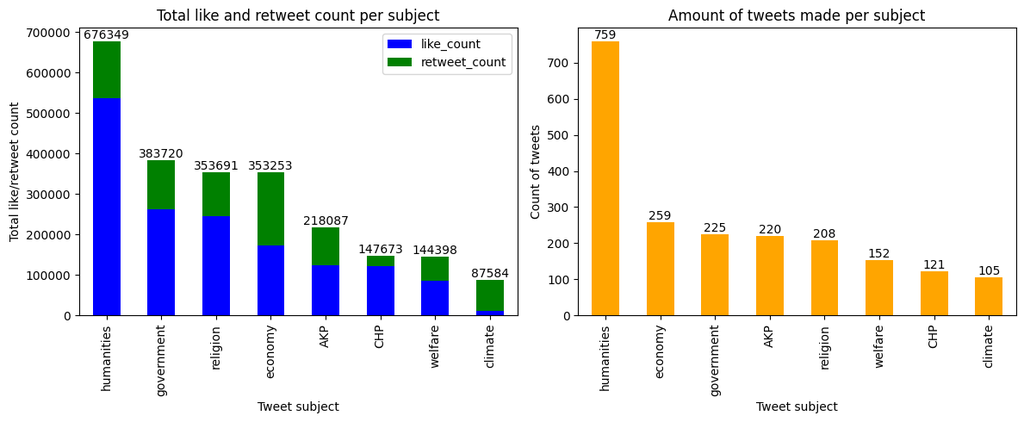

```python
grouped_counts = df.groupby('Subject')[['like_count', 'retweet_count']].sum()
grouped_counts1 = grouped_counts.sort_values(by=['like_count', 'retweet_count'], ascending=False)
grouped_tweets = df.groupby('Subject')['Tweet'].count()
grouped_tweets1 = grouped_tweets.sort_values(ascending=False)

fig, axs = plt.subplots(1, 2, figsize=(12, 5))

# First subplot
grouped_counts1.plot(kind='bar', stacked=True, color=['blue', 'green'], ax=axs[0])
for i, v in enumerate(grouped_counts1.sum(axis=1)):
    axs[0].text(i, v, int(v), ha='center', va='bottom')
axs[0].set_xlabel('Tweet subject')
axs[0].set_ylabel('Total like/retweet count')
axs[0].set_title('Total like and retweet count per subject')

# Second subplot
grouped_tweets1.plot(kind='bar', color='orange', ax=axs[1])
for i, v in enumerate(grouped_tweets1):
    axs[1].text(i, v, int(v), ha='center', va='bottom')
axs[1].set_xlabel('Tweet subject')
axs[1].set_ylabel('Count of tweets')
axs[1].set_title('Amount of tweets made per subject')

plt.tight_layout()

plt.show()
```

# Conclusion

Looking at the left chart, the subject humanities has an overwhelmingly larger engagement amount compared to the other subjects. Engagement however, is not the same as outreach. Due to the limitations of the dataset and also on what Twitter / X would allow to be called for in their API, we would have no idea on how many users have actually seen these tweets, or scrolled through them compared to how many liked and/or retweeted them. Number of comments and replies is also a limitation in determining ACTUAL engagement/outreach.

But, we can talk about engagement, in this case it means the amount of likes and retweets a tweet has.

Taking my first conclusion into consideration while looking at the right chart. It is obvious that "humanities" has a lot more tweets talking about that subject, so the results of the left chart that looks at engagement could be skewed by that.

There again it seems that 'humanities' has an overwhelmingly larger amount of tweets made compared to the other subjects.

With this I can also see where I have to balance when starting my machine learning model. Knowing I have a unbalanced division of tweets through various subjects, I will most likely undersample the "Humanities" tweets to create a better model training and testing split.

# Tweet activity analysis

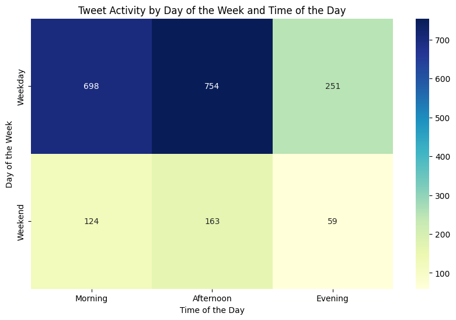

```python
heatmap_data = df.pivot_table(index='dotw', columns='totd', values='tweet_created_at', aggfunc='count')

days_order = ['Weekday', 'Weekend']
times_order = ['Morning', 'Afternoon', 'Evening']

plt.figure(figsize=(10, 6))
sns.heatmap(heatmap_data, cmap='YlGnBu', annot=True, fmt='d', xticklabels=times_order, yticklabels=days_order)
plt.title('Tweet Activity by Day of the Week and Time of the Day')
plt.xlabel('Time of the Day')
plt.ylabel('Day of the Week')

plt.show()
```

# Conclusion

# Preprocessing

## 🆔 Encoding

Here the labels are mapped to integers. Basically classing them again, but now with numbers instead of text.

- government
- humanities (civil rights, hate-speech etc.)
- economy (inflation, rent, taxes etc.)
- climate
- religion
- welfare
- AKP (AK PARTY - erdogan)
- CHP (CH PARTY - kilicdaroglu)

I'm not using the "unspecific" label because it has no use for my model, and using it only makes the balance of my model worse because of its small sample size.

```python
label_map = {"government": 0, "humanities": 1, "economy": 2, "climate": 3, "religion": 4, "welfare": 5, "AKP": 6, "CHP": 7}
df["Target"] = df["Subject"].map(label_map)
df.sample(10)
```

|  | tweet_created_at | source | Tweet | like_count | retweet_count | Label | Subject | dotw | totd | Target |
| --- | --- | --- | --- | --- | --- | --- | --- | --- | --- | --- |
| 11975 | 2021-10-14 15:04:00+00:00 | Twitter for iOS | Eğitim fırsatları, dezavantajlı çocukların yeteneklerini ortaya çıkarır. | 131 | 3 | NaN | welfare | Weekday | Afternoon | 5 |
| 10994 | 2021-10-27 17:45:43+00:00 | UNDEFINED | adam bunu sikiyorsa hay benim heykel sikimin bahtına sokam | 38 | 34 | Negatif | humanities | Weekday | Evening | 1 |
| 8144 | 2021-08-15 05:29:00+00:00 | Twitter for iOS | parayla zevk falan olmaz ben fahişe değilim sadece zevk sikişir zevkime bakarım | 2 | 2 | Negatif | humanities | Weekend | Morning | 1 |
| 11672 | 2021-04-16 17:19:23+00:00 | Twitter for iOS | Din, insanların birbirleriyle daha iyi anlaşmalarına yardımcı olabilir. | 11 | 9 | NaN | religion | Weekday | Evening | 4 |
| 11676 | 2021-04-16 16:50:02+00:00 | Twitter for iOS | Din, insanların bir arada daha iyi yaşamalarına yardımcı olabilir. | 41 | 1802 | NaN | religion | Weekday | Afternoon | 4 |
| 10352 | 2021-08-18 14:37:00+00:00 | UNDEFINED | lber hoca nın dedigi çocuklarimız şeker takibi icin sate parmaklarını deldirmek istemiyorum gece huzurlu uykularindan sıçramayla uyanmak büyüyüp gelişmeleri icin hatta hayta kalmak icin önemli ölç... | 13765 | 1802 | Pozitif | welfare | Weekday | Afternoon | 5 |
| 11760 | 2021-12-08 15:56:54+00:00 | Twitter Web App | İçsel huzur bulmada yardımcıdır. | 132 | 154 | NaN | religion | Weekday | Afternoon | 4 |
| 183 | 2021-12-13 15:04:34+00:00 | Twitter for iOS | rabb im sağlık shat uzun ömürler versin inşallah | 44 | 15 | Pozitif | religion | Weekday | Afternoon | 4 |
| 11381 | 2021-10-07 07:29:27+00:00 | Twitter for Mac | Gelir eşitsizliği, toplumsal dengesizliği artırabilir. | 257 | 543 | NaN | economy | Weekday | Morning | 2 |
| 9228 | 2021-01-13 14:55:00+00:00 | Twitter for iOS | bir kürt cumhurbaşkanı olur başbakanıda olur oldu ülkede kürdün olamiycağı tek kürt olamıyor ht | 0 | 1 | Pozitif | AKP | Weekday | Afternoon | 6 |

Here all text inside the tweet is parsed into a vectorizer that sees every word in the text but translated in numbers (i.e. making it comprehensible for the machine).

I added a list of stop words to make sure the vectorizer doesn't take them into account in its vocabulary. These stop words are very common, but they don't neccesarily correlate to a subject being spoken about. So by excluding them from the vocabulary of the vectorizer, it instead looks for "better" words to use in its place. Giving a better result in accuracy.

(My old model in an earlier iteration went up 20% in accuracy just by adding a list of stop words)

```python
sample_size = 2049
max_words = 84
min_df = .01

df = df.sample(sample_size, random_state=random_state)
from sklearn.feature_extraction.text import TfidfVectorizer

custom_stop_words = [
    'a',
    'acaba',
    'altı',
    'altmış',
    'ama',
    'ancak',
    'arada',
    'artık',
    'asla',
    'aslında',
    'aslında',
    'ayrıca',
    'az',
    'bana',
    'bazen',
    'bazı',
    'bazıları',
    'belki',
    'ben',
    'benden',
    'beni',
    'benim',
    'beri',
    'beş',
    'bile',
    'bilhassa',
    'bin',
    'bir',
    'biraz',
    'birçoğu',
    'birçok',
    'biri',
    'birisi',
    'birkaç',
    'birşey',
    'biz',
    'bizden',
    'bize',
    'bizi',
    'bizim',
    'böyle',
    'böylece',
    'bu',
    'buna',
    'bunda',
    'bundan',
    'bunlar',
    'bunları',
    'bunların',
    'bunu',
    'bunun',
    'burada',
    'bütün',
    'çoğu',
    'çoğunu',
    'çok',
    'çünkü',
    'da',
    'daha',
    'dahi',
    'dan',
    'de',
    'defa',
    'değil',
    'diğer',
    'diğeri',
    'diğerleri',
    'diye',
    'doksan',
    'dokuz',
    'dolayı',
    'dolayısıyla',
    'dört',
    'e',
    'edecek',
    'eden',
    'ederek',
    'edilecek',
    'ediliyor',
    'edilmesi',
    'ediyor',
    'eğer',
    'elbette',
    'elli',
    'en',
    'etmesi',
    'etti',
    'ettiği',
    'ettiğini',
    'fakat',
    'falan',
    'filan',
    'gene',
    'gereği',
    'gerek',
    'gibi',
    'göre',
    'hala',
    'halde',
    'halen',
    'hangi',
    'hangisi',
    'hani',
    'hatta',
    'hem',
    'henüz',
    'hep',
    'hepsi',
    'her',
    'herhangi',
    'herkes',
    'herkese',
    'herkesi',
    'herkesin',
    'hiç',
    'hiçbir',
    'hiçbiri',
    'i',
    'ı',
    'için',
    'içinde',
    'iki',
    'ile',
    'ilgili',
    'ise',
    'işte',
    'itibaren',
    'itibariyle',
    'kaç',
    'kadar',
    'karşın',
    'kendi',
    'kendilerine',
    'kendine',
    'kendini',
    'kendisi',
    'kendisine',
    'kendisini',
    'kez',
    'ki',
    'kim',
    'kime',
    'kimi',
    'kimin',
    'kimisi',
    'kimse',
    'kırk',
    'madem',
    'mi',
    'mı',
    'milyar',
    'milyon',
    'mu',
    'mü',
    'nasıl',
    'ne',
    'neden',
    'nedenle',
    'nerde',
    'nerede',
    'nereye',
    'neyse',
    'niçin',
    'nin',
    'nın',
    'niye',
    'nun',
    'nün',
    'o',
    'öbür',
    'olan',
    'olarak',
    'oldu',
    'olduğu',
    'olduğunu',
    'olduklarını',
    'olmadı',
    'olmadığı',
    'olmak',
    'olması',
    'olmayan',
    'olmaz',
    'olsa',
    'olsun',
    'olup',
    'olur',
    'olur',
    'olursa',
    'oluyor',
    'on',
    'ön',
    'ona',
    'önce',
    'ondan',
    'onlar',
    'onlara',
    'onlardan',
    'onları',
    'onların',
    'onu',
    'onun',
    'orada',
    'öte',
    'ötürü',
    'otuz',
    'öyle',
    'oysa',
    'pek',
    'rağmen',
    'sana',
    'sanki',
    'sanki',
    'şayet',
    'şekilde',
    'sekiz',
    'seksen',
    'sen',
    'senden',
    'seni',
    'senin',
    'şey',
    'şeyden',
    'şeye',
    'şeyi',
    'şeyler',
    'şimdi',
    'siz',
    'siz',
    'sizden',
    'sizden',
    'size',
    'sizi',
    'sizi',
    'sizin',
    'sizin',
    'sonra',
    'şöyle',
    'şu',
    'şuna',
    'şunları',
    'şunu',
    'ta',
    'tabii',
    'tam',
    'tamam',
    'tamamen',
    'tarafından',
    'trilyon',
    'tüm',
    'tümü',
    'u',
    'ü',
    'üç',
    'un',
    'ün',
    'üzere',
    'var',
    'vardı',
    've',
    'veya',
    'ya',
    'yani',
    'yapacak',
    'yapılan',
    'yapılması',
    'yapıyor',
    'yapmak',
    'yaptı',
    'yaptığı',
    'yaptığını',
    'yaptıkları',
    'ye',
    'yedi',
    'yerine',
    'yetmiş',
    'yi',
    'yı',
    'yine',
    'yirmi',
    'yoksa',
    'yu',
    'yüz',
    'zaten',
    'zira'
    ]

vectorizer = TfidfVectorizer(max_features=max_words, min_df=min_df, stop_words=custom_stop_words)
X_vectorized = vectorizer.fit_transform(df["Tweet"]).toarray()
X_vectorized.shape
```

```
(2049, 84)
```

By printing its vocabulary, I can check to make sure I didn't forget some stop words, or look at if some words don't bring a lot of weight.

```python
vectorizer.vocabulary_
```

```
{'dini': 20,
 'toplumsal': 66,
 'türkiye': 69,
 'uluslararası': 70,
 'siyasi': 63,
 'kılıçdaroğlu': 38,
 'ekonomik': 22,
 'fazla': 27,
 'yardımcı': 75,
 'olabilir': 40,
 'bi': 12,
 'siktir': 62,
 'git': 29,
 'amk': 4,
 'korumak': 37,
 'politikaları': 44,
 'teşvik': 65,
 'ak': 1,
 'veren': 72,
 'göt': 30,
 'sik': 52,
 'sikeceksin': 53,
 'klim': 36,
 'değişikliği': 18,
 'gelir': 28,
 'sikem': 54,
 'sağlık': 49,
 'devam': 16,
 'allah': 3,
 'cumhurbaşkanı': 15,
 'iş': 33,
 'kamu': 34,
 'iyi': 32,
 'eğitim': 26,
 'sikiş': 61,
 'sex': 51,
 'türk': 68,
 'porno': 45,
 'azdım': 10,
 'çevre': 78,
```

[output cut: 29 more lines]

```
 'aq': 8,
 'sadece': 47,
 'erdoğan': 25,
 'önemlidir': 81,
 'çocuğu': 79,
 'toplumun': 67,
 'ananı': 6,
 'sosyal': 64,
 'sağlıyor': 50,
 'ın': 82,
 'karşı': 35,
 'şsizlik': 83,
 'dünya': 21,
 'enerji': 24,
 'veriyor': 73}
```

There are a few words in there that don't bring a lot of weight nessecarily, but by excluding them my model dropped almost 10%. By keeping them my model performs better with also a really low standard deviation when evaluating the variety of its perforamance through different subsets of data.

So therefore I think it is justified to keep them if it means a better performing model.

### Under- / Oversampling

As I explained while I was exploring my data, I am going to undersample my dataset. I am going to draw that chart again so we can compare the before/after results.

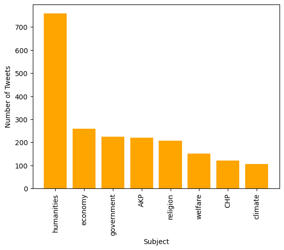

```python
grouped_tweets = df.groupby('Subject')['Tweet'].count()
grouped_tweets_sorted = grouped_tweets.sort_values(ascending=False)

plt.bar(grouped_tweets_sorted.index, grouped_tweets_sorted, color='orange')

plt.xlabel('Subject')
plt.ylabel('Number of Tweets')
plt.xticks(rotation=90, ha='center')

plt.show()
```

Because my dataset isn't very well balanced as you might have seen in the first chart, or read in my conclusion, I am going to undersample some classes. "humanities" to be specific. This so the train/test split will be more balanced thus giving better prediction results for the other classes.

I'm doing this with RandomUnderSampler, by specifiying the sampling strategy in its parameters, I can tell it to undersample the majority class. Giving me a better fit overall than if I didn't optimize the split.

I chose to grab 300 samples from the humanities class to be close to the second highest class, which is economy

```python
X = pandas.DataFrame(X_vectorized)
X[max_words] = df["Tweet"].values
y = df["Target"]
X

from imblearn.under_sampling import RandomUnderSampler

rus = RandomUnderSampler(random_state=42, sampling_strategy={1:300})
X, y = rus.fit_resample(X, y)
```

Now that we have undersampled humanities, let's draw both charts next to each other and compare the results

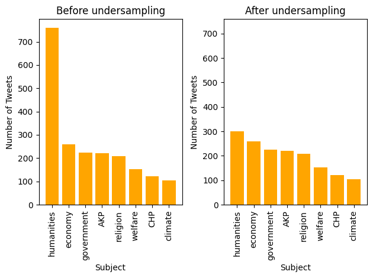

```python
grouped_tweets = df.groupby('Subject')['Tweet'].count()
grouped_tweets_sorted = grouped_tweets.sort_values(ascending=False)

max_value = grouped_tweets_sorted.max()

# First subplot
plt.subplot(1, 2, 1)
plt.bar(grouped_tweets_sorted.index, grouped_tweets_sorted, color='orange')
plt.xlabel('Subject')
plt.ylabel('Number of Tweets')
plt.title('Before undersampling')
plt.xticks(rotation=90, ha='center')

labelTarget_map = {0:"government", 1:"humanities", 2:"economy", 3:"climate", 4:"religion", 5:"welfare", 6:"AKP", 7:"CHP"}
a = pandas.DataFrame(X)
b = pandas.concat([a, y], axis=1)
b["Subject"] = b["Target"].map(labelTarget_map)

# Second subplot
plt.subplot(1, 2, 2)
grouped_tweets = b.groupby('Subject')[84].count()
grouped_tweets1 = grouped_tweets.sort_values(ascending=False)

plt.bar(grouped_tweets1.index, grouped_tweets1, color='orange')
plt.xlabel('Subject')
plt.ylabel('Number of Tweets')
plt.title('After undersampling')
plt.xticks(rotation=90, ha='center')
plt.ylim(0, max_value)
plt.tight_layout()

plt.show()
```

### Splitting into train/test

```python
from sklearn.model_selection import train_test_split
X_train, X_test, y_train, y_test = train_test_split(X, y, test_size=.2, random_state=random_state)
X_train = X_train.drop([max_words], axis=1)
X_train
```

|  | 0 | 1 | 2 | 3 | 4 | 5 | 6 | 7 | 8 | 9 | ... | 74 | 75 | 76 | 77 | 78 | 79 | 80 | 81 | 82 | 83 |
| --- | --- | --- | --- | --- | --- | --- | --- | --- | --- | --- | --- | --- | --- | --- | --- | --- | --- | --- | --- | --- | --- |
| 1970 | 0.00 | 0.00 | 0.00 | 0.00 | 0.00 | 0.00 | 0.00 | 0.00 | 0.00 | 0.00 | ... | 0.00 | 0.00 | 0.00 | 0.00 | 0.00 | 0.00 | 0.00 | 0.00 | 0.00 | 0.00 |
| 1111 | 0.00 | 0.00 | 0.00 | 0.00 | 0.00 | 0.00 | 0.00 | 0.00 | 0.00 | 0.00 | ... | 0.00 | 0.00 | 0.00 | 0.00 | 0.00 | 0.00 | 0.00 | 0.00 | 0.00 | 0.00 |
| 1292 | 0.00 | 0.00 | 0.00 | 0.00 | 0.00 | 0.00 | 0.00 | 0.00 | 0.00 | 0.00 | ... | 0.00 | 0.00 | 0.00 | 0.00 | 0.00 | 0.00 | 0.00 | 0.00 | 0.00 | 0.00 |
| 944 | 0.00 | 0.00 | 0.00 | 0.00 | 0.00 | 0.00 | 0.00 | 0.00 | 0.00 | 0.00 | ... | 0.00 | 0.00 | 0.00 | 0.00 | 0.00 | 0.00 | 0.00 | 0.00 | 0.00 | 0.75 |
| 308 | 0.00 | 0.00 | 0.00 | 0.00 | 0.00 | 0.00 | 0.00 | 0.00 | 0.00 | 0.00 | ... | 0.00 | 0.00 | 0.00 | 0.00 | 0.00 | 0.00 | 0.00 | 0.00 | 0.00 | 0.00 |
| ... | ... | ... | ... | ... | ... | ... | ... | ... | ... | ... | ... | ... | ... | ... | ... | ... | ... | ... | ... | ... | ... |
| 349 | 0.00 | 0.00 | 0.00 | 0.00 | 0.00 | 0.00 | 0.00 | 0.00 | 0.00 | 0.00 | ... | 0.00 | 0.00 | 0.00 | 0.00 | 0.00 | 0.00 | 0.00 | 0.00 | 0.00 | 0.00 |
| 2014 | 0.00 | 0.00 | 0.00 | 0.00 | 0.00 | 0.00 | 0.00 | 0.00 | 0.00 | 0.00 | ... | 0.00 | 0.00 | 0.00 | 0.00 | 0.00 | 0.00 | 0.00 | 0.00 | 0.00 | 0.00 |
| 837 | 0.00 | 0.00 | 0.00 | 0.00 | 0.00 | 0.00 | 0.00 | 0.00 | 0.00 | 0.00 | ... | 0.00 | 0.00 | 0.00 | 0.00 | 0.00 | 0.00 | 0.00 | 0.00 | 0.00 | 0.00 |
| 1711 | 0.00 | 0.00 | 0.00 | 0.00 | 0.00 | 0.00 | 0.00 | 0.00 | 0.00 | 0.00 | ... | 0.00 | 0.00 | 0.00 | 0.00 | 0.00 | 0.00 | 0.00 | 0.00 | 0.00 | 0.00 |
| 1261 | 0.00 | 0.00 | 0.00 | 0.00 | 0.00 | 0.00 | 0.00 | 0.00 | 0.00 | 0.00 | ... | 0.00 | 0.00 | 0.00 | 0.00 | 0.00 | 0.00 | 0.00 | 0.00 | 0.00 | 0.00 |

1272 rows × 84 columns

# Modelling

Here I will apply the KNN model and a SVC model and print their accuracy scores to compare them. If all previous steps were done well, the SVC should be able to have a higher accuracy because of its more complex algorithm. With that complexity however also comes in more fine tuning to get it right.

```python
from sklearn.neighbors import KNeighborsClassifier

model = KNeighborsClassifier(n_neighbors=5)
model.fit(X_train, y_train)
X_test_messages = X_test[max_words]
X_test = X_test.drop([max_words], axis=1)
score = model.score(X_test, y_test)
print("Accuracy:", score)
```

```
Accuracy: 0.6446540880503144
```

```python
from sklearn.svm import SVC

model = SVC(probability=True, class_weight="balanced")
model.fit(X_train, y_train)
score = model.score(X_test, y_test)
print("Accuracy:", score)
```

```
Accuracy: 0.720125786163522
```

As you can see above, the SVC model has a higher accuracy of 72%! This is a very decent result considering this project. For that reason I will be using SVC as the definite model.

To evaluate the performance of my model, I will be using k-fold cross-validation. The goal here is to do so while considering its generalization capabilities and possibly see if more optimalization is needed to reduce the risk of overfitting for example. It provides a decent estimate by using different subsets of data, and also looks at the variability of the model.

```python
X = X.drop([max_words], axis=1)

X
```

|  | 0 | 1 | 2 | 3 | 4 | 5 | 6 | 7 | 8 | 9 | ... | 74 | 75 | 76 | 77 | 78 | 79 | 80 | 81 | 82 | 83 |
| --- | --- | --- | --- | --- | --- | --- | --- | --- | --- | --- | --- | --- | --- | --- | --- | --- | --- | --- | --- | --- | --- |
| 7 | 0.00 | 0.00 | 0.00 | 0.00 | 0.00 | 0.00 | 0.00 | 0.00 | 0.00 | 0.00 | ... | 0.00 | 0.00 | 0.00 | 0.00 | 0.00 | 0.00 | 0.00 | 0.00 | 0.00 | 0.00 |
| 8 | 0.00 | 0.00 | 0.00 | 0.00 | 0.00 | 0.00 | 0.00 | 0.00 | 0.00 | 0.00 | ... | 0.00 | 0.00 | 0.00 | 0.00 | 0.00 | 0.00 | 0.00 | 0.00 | 0.00 | 0.00 |
| 12 | 0.00 | 0.00 | 0.00 | 0.00 | 0.00 | 0.00 | 0.00 | 0.00 | 0.00 | 0.00 | ... | 0.00 | 0.00 | 0.00 | 0.00 | 0.00 | 0.00 | 0.00 | 0.00 | 0.00 | 0.00 |
| 19 | 0.00 | 0.00 | 0.00 | 0.00 | 0.00 | 0.00 | 0.00 | 0.00 | 0.00 | 0.00 | ... | 0.00 | 0.00 | 0.00 | 0.00 | 0.00 | 0.00 | 0.00 | 0.00 | 0.00 | 0.00 |
| 22 | 0.00 | 0.00 | 0.00 | 0.00 | 0.00 | 0.00 | 0.00 | 0.00 | 0.00 | 0.00 | ... | 0.00 | 0.00 | 0.00 | 0.00 | 0.00 | 0.00 | 0.00 | 0.00 | 0.00 | 0.00 |
| ... | ... | ... | ... | ... | ... | ... | ... | ... | ... | ... | ... | ... | ... | ... | ... | ... | ... | ... | ... | ... | ... |
| 1865 | 0.00 | 0.00 | 0.00 | 0.00 | 0.00 | 0.00 | 0.00 | 0.00 | 0.00 | 0.00 | ... | 0.00 | 0.00 | 0.00 | 0.00 | 0.00 | 0.00 | 0.00 | 0.00 | 0.00 | 0.00 |
| 1882 | 0.00 | 0.00 | 0.00 | 0.00 | 0.00 | 0.00 | 0.00 | 0.00 | 0.00 | 0.00 | ... | 0.00 | 0.00 | 0.00 | 0.00 | 0.00 | 0.00 | 0.00 | 0.00 | 0.00 | 0.00 |
| 1908 | 0.00 | 0.00 | 0.00 | 0.00 | 0.00 | 0.00 | 0.00 | 0.00 | 0.00 | 0.00 | ... | 0.00 | 0.00 | 0.00 | 0.00 | 0.00 | 0.00 | 0.00 | 0.00 | 0.00 | 0.00 |
| 1959 | 0.00 | 0.00 | 0.00 | 0.00 | 0.00 | 0.00 | 0.00 | 0.00 | 0.00 | 0.00 | ... | 0.00 | 0.00 | 0.00 | 0.00 | 0.00 | 0.00 | 0.00 | 0.00 | 0.00 | 0.00 |
| 1977 | 0.00 | 0.00 | 0.00 | 0.00 | 0.00 | 0.00 | 0.00 | 0.00 | 0.00 | 0.00 | ... | 0.00 | 0.00 | 0.00 | 0.00 | 0.00 | 0.00 | 0.00 | 0.00 | 0.00 | 0.00 |

1590 rows × 84 columns

But, because my dataset is still fairly imbalanced. Assessing the performance of my model could be done better with Stratified K-Fold instead.

This because it addresses an issue in imbalanced datasets; which is ensuring the evaluation of the model is done fairly and represantative for all classes, including those with fewer samples.

It helps mitigate the bias by ensuring that each fold has a representative sample of all classes, making it more difficult if you will for the model to simply memorize the majority class.

```python
from sklearn.model_selection import cross_val_score
from sklearn.model_selection import StratifiedKFold


kfold = StratifiedKFold(shuffle=True, random_state=42)

scores = cross_val_score(model, X, y, cv=kfold)

print("Cross-Validation Scores:", scores)
print("Mean Accuracy: {:.2f}%".format(scores.mean() * 100))
print("Standard Deviation: {:.5f}".format(scores.std()))
```

```
Cross-Validation Scores: [0.69811321 0.70125786 0.70125786 0.68553459 0.77672956]
Mean Accuracy: 71.26%
Standard Deviation: 0.03260
```

On average my model has an accuracy of 71.26%, with a relatively low standard deviation of 0,03. With that it could be said that my model's performance is decently stable and consistent across different subsets of data.

However, this doesn't always mean everything is fine and dandy. You should always consider other factors and domain-specific metrics when evaluating the overall effectiveness of your model.

In my situation as mentioned previously, its performance is decently stable and consistent so I am satisfied with the results for my type of data.

# Evaluation

Every tweet in the set is given a prediction here with the true subject next to it. You can see for each subject how much % it thinks it belongs to, the highest percentage being the prediction. Also the real value is shown next to that. Together with the actual text so people can observe the answers themselves and see in a literal way how it is performing.

```python
pred = model.predict_proba(X_test)
predictions = pandas.DataFrame(pred, columns=label_map.keys())
predictions["truth"] = y_test.map(dict((v,k) for k, v in label_map.items())).values
predictions["text"] = X_test_messages.values
predictions.sample(15)
```

|  | government | humanities | economy | climate | religion | welfare | AKP | CHP | truth | text |
| --- | --- | --- | --- | --- | --- | --- | --- | --- | --- | --- |
| 68 | 0.65 | 0.08 | 0.03 | 0.10 | 0.04 | 0.04 | 0.06 | 0.01 | government | vatan bayrak diyen pis sahtekarlar |
| 293 | 0.10 | 0.05 | 0.53 | 0.08 | 0.08 | 0.14 | 0.02 | 0.00 | humanities | bugün bir köpeğe tecavüz edildi onlar açık onlar kuyruk salladı sapık zihniyetinizi sikmeye kaldı |
| 37 | 0.10 | 0.05 | 0.53 | 0.08 | 0.08 | 0.14 | 0.02 | 0.00 | government | maske takmanın zorunlu olduğu spanyol gribi yılları kadının göğsünde maskeni tak hapse gir yazıyor lk günlerde gerçekten maske takmayanlar hapse atılıyordu sonra hapiste bulaş riski yüksek olduğun... |
| 73 | 0.01 | 0.01 | 0.01 | 0.00 | 0.01 | 0.01 | 0.95 | 0.00 | AKP | AK Parti, insan haklarına saygıyı teşvik etmek için çaba sarf ediyor. |
| 268 | 0.10 | 0.05 | 0.53 | 0.08 | 0.08 | 0.14 | 0.02 | 0.00 | humanities | ölüm sayılarına bakılıyor yanlış öncede yazmıştım covid beyinde hasar bırakıyor beyin iltihaplanması çeşitli psikozlar kronik majör depresyon delirium başka psikiyatrik hastalıklara sebep olabiliyor |
| 6 | 0.07 | 0.09 | 0.04 | 0.02 | 0.68 | 0.05 | 0.04 | 0.00 | religion | Dini hoşgörüyü desteklemeliyiz. |
| 306 | 0.05 | 0.03 | 0.02 | 0.01 | 0.02 | 0.02 | 0.86 | 0.00 | AKP | AKP ve MHP yasa tekliflerine red vermeye devam edip 2000 sonrası SGK girişlilere kademe konusunda adım atmaz ise, yerel seçimde İstanbul'da yoğun çalışan nüfusun oyu ister istemez dernek temsilcil... |
| 266 | 0.01 | 0.01 | 0.01 | 0.01 | 0.01 | 0.01 | 0.95 | 0.00 | AKP | sizini münafık şerefiz bir grup görmedim akp lgbt açılımı yapsa hepiniz bizlerde gayız diyip |
| 121 | 0.04 | 0.02 | 0.03 | 0.01 | 0.05 | 0.03 | 0.02 | 0.81 | CHP | Siyasi partilerin toplumun farklı kesimlerini temsil etmeleri önemlidir. |
| 115 | 0.61 | 0.05 | 0.06 | 0.02 | 0.06 | 0.08 | 0.06 | 0.07 | CHP | Türkiye'nin dış politika vizyonu, uluslararası ilişkileri şekillendirir. |
| 237 | 0.07 | 0.50 | 0.19 | 0.05 | 0.15 | 0.02 | 0.03 | 0.00 | climate | doğanın dilaranın bacaklarından kıl var demesi cnrkxkemck sonrasında kısa bi bakışma |
| 142 | 0.06 | 0.76 | 0.04 | 0.02 | 0.04 | 0.03 | 0.04 | 0.00 | humanities | babani sik im |
| 189 | 0.10 | 0.05 | 0.53 | 0.08 | 0.08 | 0.14 | 0.02 | 0.00 | humanities | fahişe olmuş beyinlerin ispatı yoktur yüzden vesikası olmayan herkes kendini namuslu zanneder |
| 147 | 0.36 | 0.12 | 0.19 | 0.04 | 0.08 | 0.12 | 0.07 | 0.01 | economy | İş güvencesi, çalışanların refahını artırıyor. |
| 307 | 0.21 | 0.08 | 0.10 | 0.43 | 0.06 | 0.06 | 0.05 | 0.01 | climate | Karbon emisyonlarını azaltmak, gezegenimizi korumak için kritik. |

A classification report gives information about the precision and recall. Also the classification report can be ran on the test set as well as on the train set. If very different outcomes are presented, the model may be overfitted/underfitted.

The accuracy of the train set is slightly higher than of the test set, this means that it is probably overfitting the model slightly. Despite that, I'm satisifed with the results considering the dataset.

```python
from sklearn.metrics import classification_report

pred = model.predict(X_train)
report = classification_report(y_train, pred, target_names=label_map.keys())
print("Train set")
print(report)
```

```
Train set
              precision    recall  f1-score   support

  government       0.86      0.66      0.75       189
  humanities       0.92      0.81      0.86       237
     economy       0.49      0.83      0.61       203
     climate       0.78      0.77      0.78        90
    religion       0.85      0.66      0.74       170
     welfare       0.77      0.65      0.71       124
         AKP       1.00      0.85      0.92       172
         CHP       0.82      0.99      0.90        87

    accuracy                           0.77      1272
   macro avg       0.81      0.78      0.78      1272
weighted avg       0.81      0.77      0.78      1272
```

```python
pred = model.predict(X_test)
report = classification_report(y_test, pred, target_names=label_map.keys())
print("Test set")
print(report)
```

```
Test set
              precision    recall  f1-score   support

  government       0.60      0.50      0.55        36
  humanities       0.83      0.78      0.80        63
     economy       0.47      0.71      0.57        56
     climate       0.62      0.53      0.57        15
    religion       0.93      0.74      0.82        38
     welfare       0.69      0.64      0.67        28
         AKP       0.97      0.79      0.87        48
         CHP       0.83      0.88      0.86        34

    accuracy                           0.72       318
   macro avg       0.74      0.70      0.71       318
weighted avg       0.75      0.72      0.73       318
```

# Type in any message and try for yourself what it predicts!

```python
message = "boyle devlet'den hic birsey olmaz"
message_vectorized = vectorizer.transform([message]).toarray()
inference = model.predict_proba(message_vectorized)
result = pandas.DataFrame(inference, columns=label_map.keys())
result
```

|  | government | humanities | economy | climate | religion | welfare | AKP | CHP |
| --- | --- | --- | --- | --- | --- | --- | --- | --- |
| 0 | 0.60 | 0.06 | 0.12 | 0.02 | 0.09 | 0.05 | 0.05 | 0.01 |

# Demonstration

I have set up a demo to showcase to a stakeholder, that is also an intended end-user. This is important because it can bring opportunities for the end-user to interact with my model and give me better and more valuable feedback based on their "outsider"-perspective.

### What I'd like to uncover with this demo

It's no secret that the program -- in terms of a UI/UX perspective, is not that "pretty". I'd like to hear from exactly this rough way of visualizing certain things how it could be perceived more easily by 3rd parties. Or rather, what they would like to be able to do with it in terms of functionality and features. (think about features such as: exporting to seperate datasheets for further analysis for example, or a way to convert the data to statistics and finetune a filter search)

Next to the technical aspect, I'm especially curious to gain a direction to some questions I have. Such as if I were to really launch this program into the world, have I really thought through to the consequences? To the possible pitfalls or its entire possibility in itself? Am I perhaps missing out on things? Have I forgotten about certain aspects? What would it all mean, or rather, what do I want it to mean?

Below you can see the presentation that I have prepared for the demo, it is a complete summary of Phase 1, it touches on certain aspects of this project such as why I'm doing this, a summary to my domain understanding, my goal with this project, and at the end the demo of how the program works.

### A bit of background on my stakeholder

My stakeholder asked me to keep him anonymous in terms of full names and other too literal identifying information for his own personal reasons.

Turan is a 28 year old researcher at the Turkish Statistical Institute(Türkiye İstatistik Kurumu, TÜİK), he was born in the Black Sea coast of Turkey. He got his Master in Political History in 2017 and since then has been doing all kinds of statistical research and analysis for the Turkish government.

The Turkish Statistical Institute is a similar government organization such as the CBS we have in The Netherlands.

He is unfortunately not allowed to go quite in depth in what exactly he is working on right now.

The reason I chose him as my stakeholder is because people like him could be a end-user if my project were to be continued and developed into fruition.

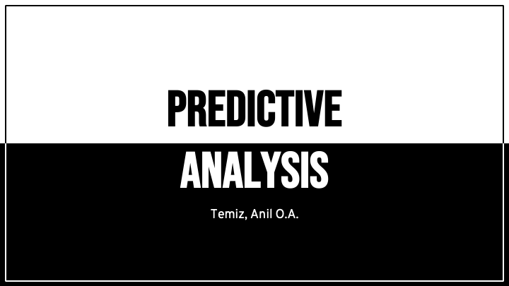

[figure not shown]

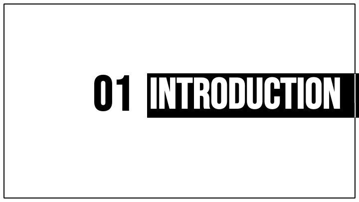

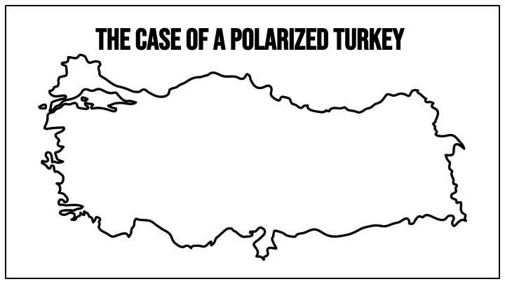

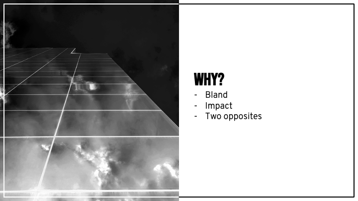

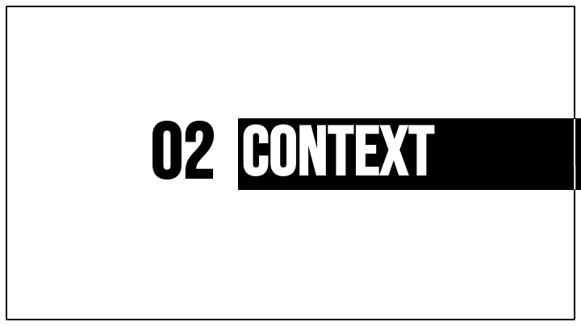

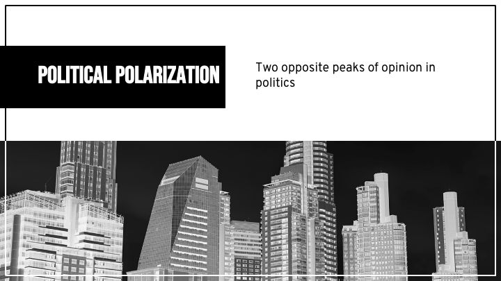

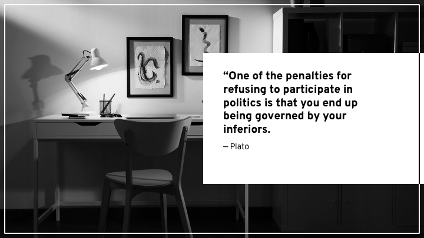

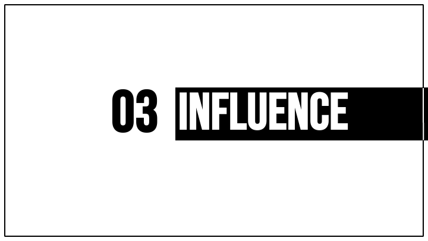

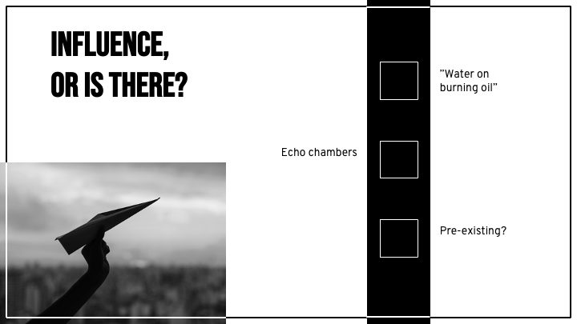

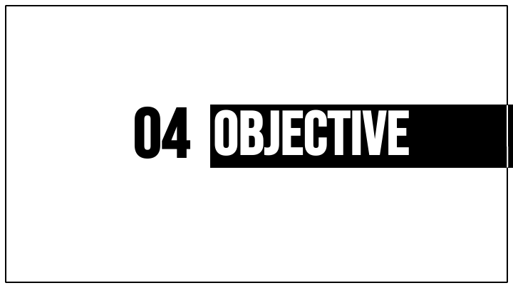

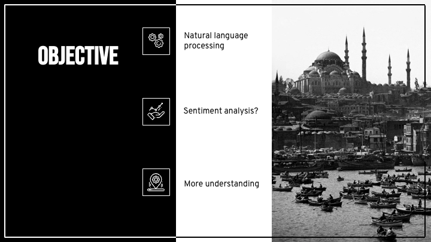

[4 more figures not shown]

# Feedback

Below I have summarized the feedback I have received with direct quotes and my own understanding of the critique point below.

This feedback was collected after being shown a demo of how my program works, and what it actually does. (as also documented in the notebook during my efforts)

1. "A interface or some kind of filtering function to be able to further zoom into certain aspects would be a good addition. If you were able to make charts with those specific boundaries of data it would be much easier to work with, and create actual insight with."

Being able to focus on relevant information, or, being able to create a better contextual understanding is crucial for bringing more insight. Just having numbers or figures or anything like that being shown in heaps of data doesn't actually tell much.

2. "If I were to use this, I would want to be able to add more categories, how it would be incoporated technically: I leave up to you. Next to this being able to see sentiment in terms of positive/negative would bring even more insight to the output."

Because there may be trends with certain subjects being spoken about, but it is also important to know what the sentiment is, is it a positive trend? Is it a negative trend? For example, climate being talked about more and more each year may indicate something negative, but if the sentiment is positive, it could then indicate a positive change in climate instead of the opposite. Nuance in this is very important.

3. "It would be great if you could somehow also incorporate like and retweet behavior"

Many twitter users don't tweet anything, but do like and retweet a lot. If there was a way to analyze this behaviour to be able to include their opinion into the analysis, it would bring even more insight.

4. "Same actually with twitter polls, you probably also have seen how much those style of tweets were used to poll certain sentiment, opinions, and general feeling during the elections especially. It would be better if you could also find a way to use that"

Same as the above, this is another way to analyze certain behaviour, being able to include this could bring a lot of added context.

### Final conclusion from Turan

"In general, this tool could be very helpful if used for a longer amount of time(as you give it more and more data). You could use it to follow, analyze, and track certain trends through time and into the future. Possibly even able to start making your own predictions, for example, if you see an upward trend over 10 years where it increases slightly each year, you could "extend" that line, so to speak. It for sure would raise a lot of new questions as time goes on.

Now I'm fairly certain the government --or any government for that matter, would already have possess something similar but in a much larger scale (and not just social media). So I'm not sure if this would be viable option for larger organizations such as government departments. But as a researcher, I can for sure see how this tool could be valuable to a lot of people. Even "smaller" functions such as a student doing research for his thesis.

It may not be the answer to solve polarization, at any long shot. But the insight generated is just a tool, what would come from that is up to the user."

# What I would like to do in the future, or have in the future if I were to continue this project.

I would like to incorporate some of the ideas that were given as feedback above. Namely with like and retweet behaviour. I think this would bring in a LOT wider opinion if also accounted for.

For one, being able to filter on verified twitter users would be interesting. To analyze if anonimity leads to more "extreme" or "radical" tweet behaviour. But then again, one could also argue that those people made those anonymous accounts with the intention from the get go to be more extreme/radical without any real "consequences".

Besides that, I would like a heap ton more of data. An actual developer twitter account so I could use their API to retrieve millions of tweet data, with also just a lot more information tied to each tweet. (such as user information, location the tweet was made from etc.)

And to then tie it all down into a nice and easy to use interface. In other words; an actual front-end.

# Final thoughts and conclusion

A lot of questions has been raised since I started, and throughout my work. Ethical questions, technical questions, and practical questions. While the technical and objective practicality can be answered in a scientific way. The ethical questions raises some concerns. With them I try to see if I genuinely thought about the possible consequences.

Could someone use this program to label people to categorize them by certain religions, ideologies etc. so that they could potentially predict or even influence certain groups of people? It is a scary thought, what if someone reverse engineered the program and by using the results, created another AI that would essentially use what it learned on what kind of word combination makes a certain subject. Then generate millions of fake tweets to reach any given goal and send them into the world? Or if my program also learned in combination what makes that certain subject negative or positive in semantics, and then use that to sway opinion?

So could a fully fruitioned product and fully developed program of my school project be launched "responsibly" into the world?

Well, that depends. It's a yes and no answer.

If it went to organizations or institutions like the CBS or any other country's equalivant, then it would be used for exactly the purpose I created it with; to analyze.

But to make it public to everyone, so also marketing companies for example, or political parties, then I'm not so sure anymore.

If someone were to monitor polarization with this tool, and that person would see based on analyzing the output on what kind of factors riot more polarization. Then theoretically they could use those specific modifiers to bring even more extremity. By monitoring their actions and words through the tweets of others for example, they can analyze what and if their actions have led to more or less polarization, on which they can adjust their behaviour to achieve any given intended goal.

And that is the difficult question to answer here, I will rephrase my main question; if this program were to be fully developed with a big investment, teams worth of developers, and an even bigger scope. Can it be responsibily launched?

If it means that consequences as I speculated above would come to fruition. Then my answer is no.

I could not stop those consequences, my goal to bring more insight to, for example, universities, institutes, researchers, would be ignored if anyone deems that other goal to be fit. I designed and created a knife to cut bread, but someone else takes it and stabs another person with it.

It has been a real journey throughout this challenge. I've learned a lot, I've researched a lot, I probably also have changed some of my views on certain things. But now it is time to close this notebook, but maybe not forever.

I've touched upon on why I chose this subject in the first place. How I wanted to do something I could be or was already passionate about. Something more fulfilling than just ticking boxes in some evaluation rubric.

This passion and curiosity has only grew even more.